# Text Classification in Python

**Created for the Text Analysis Workshop at the Transdesciplinary Institue in Applied Data Sciences (Washington University in St Louis)**

**By Ishita Gopal**

**Aknowledgement:** This notebook is the Python adaptation of Burt Monroe's [R notebook](https://burtmonroe.github.io/TextAsDataCourse/Tutorials/TADA-ClassificationV2.nb.html#support-vector-machine) from his Text as Data course that I had the oppertunity to take as a PhD student at PSU :)

# The task:

This notebook is a comprehensive guide for text classification tasks using popular machine learning techniques. It provides a deep dive into the implementation and analysis of Naive Bayes, Support Vector Machines (SVM), and Random Forests, and also covering aspects such as evaluation, interpretation, and comparison of these models.

We will work through a sentiment classification problem, using a movie reviews data set where we know the "negative" and "positive" labels for each of the movie reviews. We'll set some of these reviews aside for a test set and train our models on the remainder as a training set, using unigram presence as the features. Then we'll evaluate the predictions quantitatively as well as look at some ways to interpret what the models tell us.

We are using Pang and Lee dataset of 2000 movie reviews and the [scikit-learn](https://scikit-learn.org/) library.

This tutorial provides details on the models and is aimed at Python users. I walk throught all the steps of converting text into a vectorized format that can be input into classification models, I provide a summary of how the models work, walk throught the steps to extract feature importance from these models and vizualize them.

# Index:

Loading the Dataset  
Vectorize and Create DTM  
Naive Bayes  
Support Vector Machine  
Random Forests  
Receiver Operating Characteristic (ROC)

# Dataset

```python
import pandas as pd
reviews = pd.read_csv("https://raw.githubusercontent.com/IshitaGopal/TRIADS_workshops/main/Introduction_to_TextAnalysis/data/movie_reviews_pang02.csv")
reviews.shape
```

```
(2000, 2)
```

```python
reviews.head(2)
```

|  | text | class |
| --- | --- | --- |
| 0 | plot : two teen couples go to a church party ,... | neg |
| 1 | the happy bastard's quick movie review \ndamn ... | neg |

```python
reviews.tail(2)
```

|  | text | class |
| --- | --- | --- |
| 1998 | steven spielberg's second epic film on world w... | pos |
| 1999 | truman ( " true-man " ) burbank is the perfect... | pos |

```python
# Let's look at an example review
reviews["text"][1]
```

```
'the happy bastard\'s quick movie review \ndamn that y2k bug . \nit\'s got a head start in this movie starring jamie lee curtis and another baldwin brother ( william this time ) in a story regarding a crew of a tugboat that comes across a deserted russian tech ship that has a strangeness to it when …
```

```python
# The positive and negative classes are balanced
reviews["class"].value_counts()
```

```
class
neg    1000
pos    1000
Name: count, dtype: int64
```

```python
from sklearn.preprocessing import LabelEncoder
# Convert the class variable into an integer representing Pos and Neg
label_encoder = LabelEncoder()
reviews['class_int'] = label_encoder.fit_transform(reviews['class'])
reviews.head(2)
```

|  | text | class | class_int |
| --- | --- | --- | --- |
| 0 | plot : two teen couples go to a church party ,... | neg | 0 |
| 1 | the happy bastard's quick movie review \ndamn ... | neg | 0 |

```python
reviews['class_int'].value_counts()
```

```
class_int
0    1000
1    1000
Name: count, dtype: int64
```

Shuffle the rows to randomize the order. We dont want to train just on reviews labeled as positive (or negative). We want to represent all the categories in our training data. The `train_test_split` function will do this for us while splitting the data. We are keeping 80% labelled reviews for training our classification models and 20% of the labelled reviews for testing the performance of our models.

```python
from sklearn.model_selection import train_test_split
# Split the dataset into training and testing sets
train_data, test_data, y_train, y_test = train_test_split(
    reviews['text'], reviews['class_int'], test_size=0.2, random_state=42
)
print("Number of training samples:", train_data.shape)
print("Number of test samples:", test_data.shape)
```

```
Number of training samples: (1600,)
Number of test samples: (400,)
```

```python
# Confirm the order of the rows were shuffled
train_data.head(10)
```

```
968     while watching loser , it occurred to me that ...
240     georges polti once wrote a paper called " the ...
819     sylvester stallone has made some crap films in...
692     attention moviegoers : you are about to enter ...
420     plot : something about a bunch of kids going i...
1085     * * * * * * minor plot spoilers in review * *...
1998    steven spielberg's second epic film on world w...
365     welcome to your oh-so typical sequel . \nit tr...
1022    a fully loaded entertainment review - website ...
1240    seen september 13 , 1998 at 4 p . m at rotterd...
Name: text, dtype: object
```

# Create the doument term matrix

You can create different types of features for text classification using `scikit-learn`.

- To create word presence features, use `CountVectorizer` with `binary=True`.
- For word count features, simply use `CountVectorizer` with default settings.
- To generate TF-IDF features, use `TfidfVectorizer`, which automatically computes both term frequency (TF) and inverse document frequency (IDF) scores for each word.
- By adjusting the parameters of these vectorizers, such as `binary`, `max_df`, `min_df`, and `ngram_range`, you can customize the feature extraction process according to your specific requirements.

In our example, we will only use the word presence features (Binary Vectorizer).

```python
from sklearn.feature_extraction.text import CountVectorizer
from nltk.tokenize import word_tokenize
import nltk
nltk.download('punkt')
```

```
True
```

## Binary Vectorizer

```python
# Create a CountVectorizer instance for feature extraction
# binary = True specifies that instead of counts we are using presence of the word as a feature
vectorizer_binary = CountVectorizer(tokenizer=word_tokenize, binary=True)
```

```python
# Convert the text data into a document-term matrix
# These are our features
X_train_binary = vectorizer_binary.fit_transform(train_data)
X_test_binary = vectorizer_binary.transform(test_data)
```

```python
# The above returns sparse matrices but we can look at the numbers
X_train_binary[0:10, 10:16].todense() # 1 represents presence of the word not counts here
```

```
matrix([[0, 0, 0, 0, 0, 1],
        [0, 0, 0, 0, 0, 0],
        [0, 1, 0, 0, 0, 0],
        [0, 0, 0, 0, 0, 0],
        [1, 0, 0, 0, 0, 1],
        [1, 0, 0, 0, 0, 0],
        [0, 0, 0, 0, 0, 0],
        [1, 0, 0, 0, 0, 1],
        [1, 0, 0, 0, 0, 0],
        [0, 1, 1, 0, 0, 1]])
```

```python
# We can store the vocabulary
vocab_dict = vectorizer_binary.vocabulary_ # resturns a dictionary
vocab_list = vectorizer_binary.get_feature_names_out() # returns a list of words in alphabrtical order

print(vocab_list[:50])
```

```
['\x05' '\x13earth' '\x13goodies' '\x13if' '\x13ripley' '\x13suspend'
 '\x13they' '\x13white\x14' '\x14' '\x16' '!' '#' '$' '%' '&' "'" "''"
 "'00s" "'10" "'28" "'40s" "'50s" "'58" "'60s" "'60s/'70s" "'69" "'70"
 "'70s" "'77" "'79" "'80" "'80s" "'82" "'90" "'90s" "'92/early" "'93"
 "'94" "'95s" "'96" "'97" "'98" "'act" "'acting" "'almost" "'amateur"
 "'amusing" "'ani" "'animal" "'answer"]
```

```python
print(vocab_list[-50:])
```

```
['zingers' 'zinnemman' 'zinnia' 'zip' 'zipped' 'zippel' 'zipper' 'zippers'
 'zippy' 'zit' 'ziyi' 'zodiac' 'zoe' 'zombie' 'zombie-like'
 'zombie-stomping' 'zombies' 'zombified' 'zone' 'zones' 'zoo' 'zoo-like'
 'zookeeper' 'zookeepers' 'zoolander' 'zoologist' 'zoom' 'zoom-in'
 'zoom-ins' 'zoom-out' 'zoom-outs' 'zooming' 'zooms' 'zoot' 'zophres'
 'zorg' 'zorro' 'zucker' 'zucker/abrahams/zucker' 'zuehlke' 'zuko'
 'zukovsky' 'zulu' 'zurg' 'zweibel' 'zwick' 'zwigoff' 'zycie' '|' '||']
```

## Count Vectorizer

```python
# Use the count vectorizer instead
# Convert the text data into a document-term matrix
# These are our features
vectorizer_count = CountVectorizer(tokenizer=word_tokenize)
X_train_count = vectorizer_count.fit_transform(train_data)
X_test_count = vectorizer_count.transform(test_data)
```

```python
# Instead of presence we see frequency of words here:
X_train_count[0:10, 10:16].todense()
```

```
matrix([[ 0,  0,  0,  0,  0,  2],
        [ 0,  0,  0,  0,  0,  0],
        [ 0,  1,  0,  0,  0,  0],
        [ 0,  0,  0,  0,  0,  0],
        [13,  0,  0,  0,  0,  1],
        [ 1,  0,  0,  0,  0,  0],
        [ 0,  0,  0,  0,  0,  0],
        [ 6,  0,  0,  0,  0,  1],
        [ 1,  0,  0,  0,  0,  0],
        [ 0,  1,  1,  0,  0,  2]])
```

## Tf-idf Vectorizer

```python
from sklearn.feature_extraction.text import TfidfVectorizer
# Create TF-IDF vectorizer
tfidf_vectorizer = TfidfVectorizer()

# Fit and transform the training data
X_train_tfidf = tfidf_vectorizer.fit_transform(train_data)
# Transform the test data
X_test_tfidf = tfidf_vectorizer.transform(test_data)
```

```python
X_test_tfidf.shape
```

```
(400, 36246)
```

# Naive Bayes

Naive Bayes is a probabilistic classifier based on Bayes' theorem, which calculates the probability of a given class (e.g., positive or negative sentiment) given the input features (e.g., words in a document).

**Independence Assumption:** Naive Bayes operates under the assumption that the features (words) are conditionally independent given the class label. This is known as the "naive" assumption. In our example, Naive Bayes assumes that the presence of each word in a movie review is independent of the presence of other words, given the sentiment label (positive or negative). For example, knowing that a review contains the word "great" does not influence the likelihood of it containing the word "horrible", and vice versa. Although this assumption is very simplistic and may not hold true in practice, Naive Bayes often performs well in text classification tasks.

**Conditional Probability:** Naive Bayes calculates the conditional probability of each word given the sentiment label. For instance, it estimates the probability of seeing the word "great" in a positive review and the probability of seeing the word "horrible" in a negative review independently.The classifier combines the probabilities of individual words to calculate the overall probability of each sentiment label given the input review. It does so by multiplying the conditional probabilities of each word given the sentiment label.

**Interpretability/ Feature Importance:** Naive Bayes implicitly ranks features (words) based on their contribution to the classification decision. Words with higher conditional probabilities for a particular class are considered more important for predicting that class. This allows users to identify which words are most influential in determining the predicted class.

```python
from sklearn.naive_bayes import BernoulliNB
from sklearn.metrics import accuracy_score, classification_report, confusion_matrix
import numpy as np
```

## NB Fit:

```python
# Create an instance of the Naive Bayes classifier
classifier_nb = BernoulliNB()

# Train (fit) the classifier using the training data
classifier_nb.fit(X_train_binary, y_train)
```

```
BernoulliNB()
```

## NB Predictions:

```python
# Get (0/1) predictions for the test set
predictions_nb = classifier_nb.predict(X_test_binary)

# Get the predicted probabilities (between 0 & 1 ) for the test set
predicted_prob_nb = classifier_nb.predict_proba(X_test_binary)

# Each tuple contains a prediction and its corresponding predicted probabilities
# The first probability corresponds to the negative class (0) and the second to the positive (1)
list(zip(predictions_nb[:5], predicted_prob_nb[:5]))
```

```
[(1, array([1.22512981e-09, 9.99999999e-01])),
 (1, array([0.01576483, 0.98423517])),
 (1, array([4.96043969e-15, 1.00000000e+00])),
 (0, array([0.99524859, 0.00475141])),
 (1, array([0.14210348, 0.85789652]))]
```

```python
# the sum of these 2 probabilities will equal 1 like we see below
np.sum(predicted_prob_nb[:5], axis=1)
```

```
array([1., 1., 1., 1., 1.])
```

## NB Evaluate:

We will use **accuracy** which is a commonly used metric in machine learning as the main metric to measure the performance of a classification model because we have class balance. It represents the ratio of correctly predicted instances to the total instances in the dataset.

```python
# Evaluate the classifier
accuracy_nb = accuracy_score(y_test, predictions_nb)
print(f'Accuracy: {accuracy_nb:.2f}')

# Lets also print out the other metrics
print("\nClassification Report:")
print(classification_report(y_test, predictions_nb))
```

```
Accuracy: 0.78

Classification Report:
              precision    recall  f1-score   support

           0       0.72      0.90      0.80       199
           1       0.87      0.66      0.75       201

    accuracy                           0.78       400
   macro avg       0.80      0.78      0.78       400
weighted avg       0.80      0.78      0.78       400
```

## NB Feature importance:

```python
# Identify the most important features
feature_probabilities_nb = np.exp(classifier_nb.feature_log_prob_)
```

Note: `.feature_probabilities` are the *posterior probabilities* that a word will appear in a document of a given class, $p(w|k)$. **But** we want the posterior probability that a document is of a given class, given it contains that word, $p(k|w)$

This cab be obtained by Bayes Theorem:

$p(\text{pos} | w) = \frac{p(w | \text{pos})}{p(w | \text{pos}) + p(w | \text{neg})}$

In this equation:

$w$ is present giving us a quantitative measure of how important a token is for classifying documents into different classes.

- $p(w | \text{pos})$ is the posterior probability that the word ( w ) will appear in a positive document.
- $p(w | \text{neg})$ is the posterior probability that the word ( w ) will appear in a negative document.

This equation allows us to calculate the probability of a document belonging to a certain class (e.g., positive) given that it contains a specific word ( w ).

```python
# calculate (denominator in equation above):
total_word_likelihood = np.sum(feature_probabilities_nb, axis=0)
# Calculate the probability of each word being associated with the negative class (p(w|neg))
prob_negative_given_word = feature_probabilities_nb[0,:]/total_word_likelihood
# Calculate the probability of each word being associated with the positive class (p(w|pos))
prob_positive_given_word = feature_probabilities_nb[1,:]/total_word_likelihood
```

```python
vocab_list[np.argsort(prob_negative_given_word)[-30:][::-1]]
```

```
array(['insulting', 'hudson', 'sucks', 'unimaginative', 'leaden',
       'degenerates', 'wielding', 'horrid', 'suvari', 'mena',
       'pathetically', 'uninvolving', 'seagal', 'by-the-numbers', 'vein',
       'tedium', 'ivy', 'jumbled', 'stupidity', 'turkey', 'aimlessly',
       'nonsense', 'forsythe', 'macdonald', 'plodding', 'kidding',
       'setups', 'chevy', 'hodgepodge', 'priests'], dtype=object)
```

```python
vocab_list[np.argsort(prob_positive_given_word)[-30:][::-1]]
```

```
array(['debate', 'outstanding', 'missteps', 'addresses', 'intimate',
       'refreshingly', 'detract', 'finest', 'passage', 'deft', 'narrates',
       'embodies', 'lovingly', 'gattaca', 'symbol', 'meryl', 'soviet',
       'discussed', 'studies', 'marvelous', 'astounding', 'masterfully',
       'freed', 'fabric', 'tobey', 'lithgow', 'criticized', 'uncut',
       'online', 'magnificent'], dtype=object)
```

### Plot the feature importance:

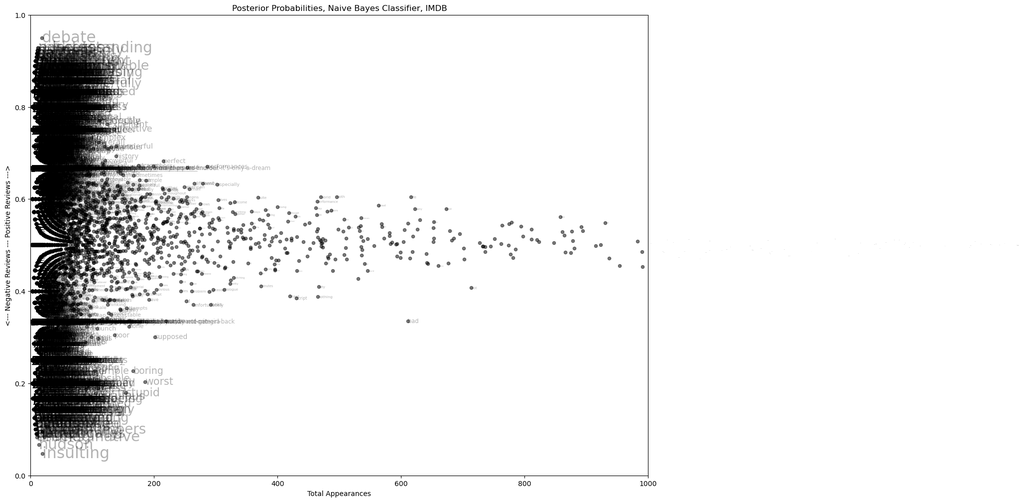

```python
# Plot weights
col_sums = np.sum(X_train_binary, axis=0).tolist()[0]
post_pos = prob_positive_given_word.tolist()

plt.figure(figsize=(16, 12))
plt.scatter(col_sums, post_pos, marker='o', color='black', alpha=0.5, s=20)
plt.title("Posterior Probabilities, Naive Bayes Classifier, IMDB")
plt.xlabel("Total Appearances")
plt.ylabel("<--- Negative Reviews --- Positive Reviews --->")
plt.xlim(0, 1000)
plt.ylim(0, 1)

# Add text labels
for i, txt in enumerate(vocab_list):
        plt.text(col_sums[i],
                 post_pos[i],
                 txt,
                 ha='left',
                 va='center',
                 alpha=.30,
                 fontsize=50*abs(.5-post_pos[i]),
                 color="black")
plt.show()
```

### Zoom into the positve words:

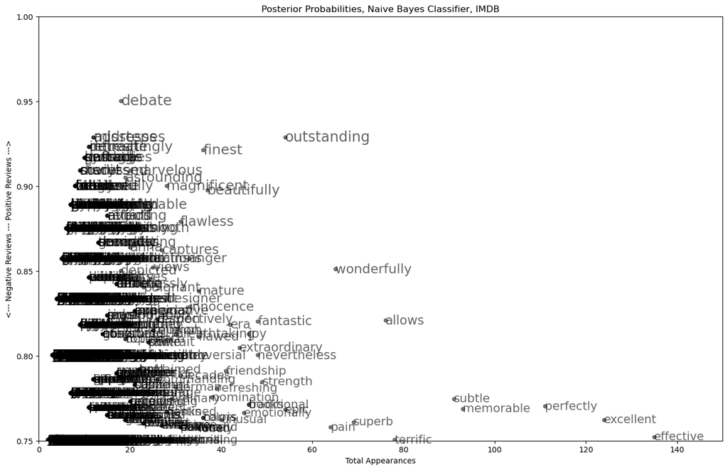

```python
# Plot weights
plt.figure(figsize=(16, 10))
plt.scatter(col_sums, post_pos, marker='o', color='black', alpha=0.5, s=20)
plt.title("Posterior Probabilities, Naive Bayes Classifier, IMDB")
plt.xlabel("Total Appearances")
plt.ylabel("<--- Negative Reviews --- Positive Reviews --->")
plt.xlim(0, 150)
plt.ylim(0.75, 1)

# Add text labels
for i, txt in enumerate(vocab_list):
    if post_pos[i]>= 0.75:
        plt.text(col_sums[i],
                 post_pos[i],
                 txt,
                 ha='left',
                 va='center',
                 alpha=.60,
                 fontsize=20*abs(post_pos[i]),
                 color="black")
plt.show()
```